# Redes Neuronales Recurrentes (RNN)

Oldemar Rodríguez

2022-11-03

# Introducción

[figure not shown]

```python
import os
import pandas as pd
import numpy as np
import matplotlib.pyplot as plt
from sklearn.model_selection import train_test_split
from sklearn.metrics import confusion_matrix
import matplotlib.image as mpimg
```

# TensorFlow y Keras

### [TensorFlow](https://www.tensorflow.org/?hl=es-419) es una biblioteca de código abierto que se utiliza para realizar tareas de Machine Learning. Desarrollado por Google para satisfacer sus necesidades de sistemas capaces de construir y entrenar redes neuronales para detectar y descifrar patrones y correlaciones, análogos al aprendizaje y razonamiento usados por los humanos.

### [Keras](https://keras.io/) es una biblioteca de software de código abierto que proporciona una interfaz Python para redes neuronales artificiales. Keras actúa como una interfaz para la biblioteca de TensorFlow. Hasta la versión 2.3, Keras admitía varios backends, incluidos TensorFlow, Microsoft Cognitive Toolkit, Theano y PlaidML. A partir de la versión 2.4, solo se admite TensorFlow. Diseñado para permitir la experimentación rápida con el Deep Learning, se centra en ser fácil de usar, modular y extensible.

### [¿Cómo instalar TensorFlow?](https://www.tensorflow.org/install/pip?hl=es-419)

## Construyendo una Red Neuronal con Keras y los datos de iris

```python
datos_iris = pd.read_csv("../datos/iris.csv", sep = ";", decimal = ".", header = 0)
datos_iris
```

```
##      s.largo  s.ancho  p.largo  p.ancho       tipo
## 0        5.1      3.5      1.4      0.2     setosa
## 1        4.9      3.0      1.4      0.2     setosa
## 2        4.7      3.2      1.3      0.2     setosa
## 3        4.6      3.1      1.5      0.2     setosa
## 4        5.0      3.6      1.4      0.2     setosa
## ..       ...      ...      ...      ...        ...
## 145      6.7      3.0      5.2      2.3  virginica
## 146      6.3      2.5      5.0      1.9  virginica
## 147      6.5      3.0      5.2      2.0  virginica
## 148      6.2      3.4      5.4      2.3  virginica
## 149      5.9      3.0      5.1      1.8  virginica
##
## [150 rows x 5 columns]
```

```python
from sklearn.preprocessing import LabelEncoder

#Dividimos los datos en variables predictoras y variable a predecir
x = np.array(datos_iris.iloc[:,0:4])
y = datos_iris["tipo"].ravel()

#Recodificamos la variable a predecir a enteros de 0 a num_clases-1
encoder = LabelEncoder()
y = encoder.fit_transform(y)

print(y)
```

```
## [0 0 0 0 0 0 0 0 0 0 0 0 0 0 0 0 0 0 0 0 0 0 0 0 0 0 0 0 0 0 0 0 0 0 0 0 0
##  0 0 0 0 0 0 0 0 0 0 0 0 0 1 1 1 1 1 1 1 1 1 1 1 1 1 1 1 1 1 1 1 1 1 1 1 1
##  1 1 1 1 1 1 1 1 1 1 1 1 1 1 1 1 1 1 1 1 1 1 1 1 1 1 2 2 2 2 2 2 2 2 2 2 2
##  2 2 2 2 2 2 2 2 2 2 2 2 2 2 2 2 2 2 2 2 2 2 2 2 2 2 2 2 2 2 2 2 2 2 2 2 2
##  2 2]
```

```python
encoder.classes_
```

```
## array(['setosa', 'versicolor', 'virginica'], dtype=object)
```

```python
#Realizamos Training-Testing
x_train, x_test, y_train, y_test = train_test_split(x, y, train_size = 0.75, random_state = 0)
```

### Construyendo una red neuronal

```python
from tensorflow.keras.models import Sequential
from tensorflow.keras.layers import Dense

# Instanciamos nuestra base. Se puede ver como una caja vacía donde vamos añadiendo elementos.
modelo = Sequential()

#Capa de entrada y primer capa oculta
#input_shape = (4,) debido a que son 4 variables predictoras
modelo.add(Dense(units = 40,activation='relu', input_shape=(4,)))

# Segunda Capa oculta
modelo.add(Dense(units = 20,activation='relu'))

# Capa de salida.
# units = 3 debido a que son 3 clases a predecir
modelo.add(Dense(units = 3, activation='sigmoid'))

# Configuramos el modelo
# Para los parámetros
modelo.compile(
  optimizer='adam', loss='sparse_categorical_crossentropy',
  metrics=['accuracy'])
```

### Entrenamos el modelo

[epochs y batch_size](https://machinelearningmastery.com/difference-between-a-batch-and-an-epoch/)

```python
modelo.fit(x_train, y_train, epochs = 200, batch_size = 16, verbose = 0)
```

```
## <keras.callbacks.History object at 0x7fefbb3e2a90>
```

### Obtenemos las predicciones

### Función evaluate

#### Obtiene la precisión global para training-testing.

```python
loss, accu = modelo.evaluate(x_test, y_test, verbose = 0)
accu
```

```
## 0.9736841917037964
```

### Función predict

```python
pred = modelo.predict(x_test)
pred[0:5]
```

```
## array([[2.7046078e-06, 4.9611542e-01, 9.9992764e-01],
##        [5.3465143e-02, 9.8418814e-01, 5.5038139e-02],
##        [9.9997592e-01, 8.9678091e-01, 1.4459700e-07],
##        [2.7627295e-06, 7.7856696e-01, 9.9960124e-01],
##        [9.9986821e-01, 8.8450414e-01, 1.5313337e-06]], dtype=float32)
```

```python
pred = np.argmax(pred, axis = -1)
print("Predicciones: ",pred, "\n")

# Recodificamos de manera inversa con el encoder que habíamos creado
```

```
## Predicciones:  [2 1 0 2 0 2 0 1 1 1 2 1 1 1 1 0 1 1 0 0 2 1 0 0 2 0 0 1 1 0 2 1 0 2 2 1 0
##  2]
```

```python
pred = encoder.inverse_transform(pred)
print(pred)
```

```
## ['virginica' 'versicolor' 'setosa' 'virginica' 'setosa' 'virginica'
##  'setosa' 'versicolor' 'versicolor' 'versicolor' 'virginica' 'versicolor'
##  'versicolor' 'versicolor' 'versicolor' 'setosa' 'versicolor' 'versicolor'
##  'setosa' 'setosa' 'virginica' 'versicolor' 'setosa' 'setosa' 'virginica'
##  'setosa' 'setosa' 'versicolor' 'versicolor' 'setosa' 'virginica'
##  'versicolor' 'setosa' 'virginica' 'virginica' 'versicolor' 'setosa'
##  'virginica']
```

```python
def indices_general(MC, nombres = None):
  precision_global = np.sum(MC.diagonal()) / np.sum(MC)
  error_global = 1 - precision_global
  precision_categoria  = pd.DataFrame(MC.diagonal()/np.sum(MC,axis = 1)).T
  if nombres!=None:
    precision_categoria.columns = nombres
  return {"Matriz de Confusión":MC, "Precisión Global":precision_global,
          "Error Global":error_global, "Precisión por categoría":precision_categoria}

# Obtenemos las etiquetas de y_test
y_test_classes = encoder.inverse_transform(y_test)

MC = confusion_matrix(y_test_classes, pred, labels = encoder.classes_)
indices = indices_general(MC, list(encoder.classes_))
for k in indices:
  print("\n%s:\n%s"%(k,str(indices[k])))
```

```
##
## Matriz de Confusión:
## [[13  0  0]
##  [ 0 15  1]
##  [ 0  0  9]]
##
## Precisión Global:
## 0.9736842105263158
##
## Error Global:
## 0.02631578947368418
##
## Precisión por categoría:
##    setosa  versicolor  virginica
## 0     1.0      0.9375        1.0
```

# Redes Neuronales Recurrentes

## Ejemplo minst

```python
import os
import re
from tensorflow.keras import Input
from tensorflow.keras.datasets import mnist
from tensorflow.keras.models import Sequential
from tensorflow.keras.layers import Dense, LSTM, SimpleRNN
from tensorflow.keras.utils import to_categorical, plot_model
import pandas as pd
from sklearn.preprocessing import StandardScaler
from sklearn.metrics import confusion_matrix, classification_report
import numpy as np
import seaborn as sn
import matplotlib.pyplot as plt

# Reproducibilidad
from numpy.random import seed
seed(1)
from tensorflow.random import set_seed
set_seed(2)
```

```python
from tensorflow.keras.utils import plot_model
from tensorflow.keras.datasets import mnist

# carga el  mnist dataset
(x_train, y_train), (x_test, y_test) = mnist.load_data()
print("x_train.shape: ", x_train.shape)
```

```
## x_train.shape:  (60000, 28, 28)
```

```python
print("y_train.shape: ", y_train.shape)
```

```
## y_train.shape:  (60000,)
```

```python
print("x_test.shape: ", x_test.shape)
```

```
## x_test.shape:  (10000, 28, 28)
```

```python
print("y_test.shape: ", y_test.shape)

#Ejemplo de una imágen
```

```
## y_test.shape:  (10000,)
```

```python
pd.set_option('expand_frame_repr', False)
print(pd.DataFrame((x_train[0])))
```

```
##     0   1   2   3    4    5    6    7    8    9    10   11   12   13   14   15   16   17   18   19   20   21   22   23  24  25  26  27
## 0    0   0   0   0    0    0    0    0    0    0    0    0    0    0    0    0    0    0    0    0    0    0    0    0   0   0   0   0
## 1    0   0   0   0    0    0    0    0    0    0    0    0    0    0    0    0    0    0    0    0    0    0    0    0   0   0   0   0
## 2    0   0   0   0    0    0    0    0    0    0    0    0    0    0    0    0    0    0    0    0    0    0    0    0   0   0   0   0
## 3    0   0   0   0    0    0    0    0    0    0    0    0    0    0    0    0    0    0    0    0    0    0    0    0   0   0   0   0
## 4    0   0   0   0    0    0    0    0    0    0    0    0    0    0    0    0    0    0    0    0    0    0    0    0   0   0   0   0
## 5    0   0   0   0    0    0    0    0    0    0    0    0    3   18   18   18  126  136  175   26  166  255  247  127   0   0   0   0
## 6    0   0   0   0    0    0    0    0   30   36   94  154  170  253  253  253  253  253  225  172  253  242  195   64   0   0   0   0
## 7    0   0   0   0    0    0    0   49  238  253  253  253  253  253  253  253  253  251   93   82   82   56   39    0   0   0   0   0
## 8    0   0   0   0    0    0    0   18  219  253  253  253  253  253  198  182  247  241    0    0    0    0    0    0   0   0   0   0
## 9    0   0   0   0    0    0    0    0   80  156  107  253  253  205   11    0   43  154    0    0    0    0    0    0   0   0   0   0
## 10   0   0   0   0    0    0    0    0    0   14    1  154  253   90    0    0    0    0    0    0    0    0    0    0   0   0   0   0
## 11   0   0   0   0    0    0    0    0    0    0    0  139  253  190    2    0    0    0    0    0    0    0    0    0   0   0   0   0
## 12   0   0   0   0    0    0    0    0    0    0    0   11  190  253   70    0    0    0    0    0    0    0    0    0   0   0   0   0
## 13   0   0   0   0    0    0    0    0    0    0    0    0   35  241  225  160  108    1    0    0    0    0    0    0   0   0   0   0
## 14   0   0   0   0    0    0    0    0    0    0    0    0    0   81  240  253  253  119   25    0    0    0    0    0   0   0   0   0
## 15   0   0   0   0    0    0    0    0    0    0    0    0    0    0   45  186  253  253  150   27    0    0    0    0   0   0   0   0
## 16   0   0   0   0    0    0    0    0    0    0    0    0    0    0    0   16   93  252  253  187    0    0    0    0   0   0   0   0
## 17   0   0   0   0    0    0    0    0    0    0    0    0    0    0    0    0    0  249  253  249   64    0    0    0   0   0   0   0
## 18   0   0   0   0    0    0    0    0    0    0    0    0    0    0   46  130  183  253  253  207    2    0    0    0   0   0   0   0
## 19   0   0   0   0    0    0    0    0    0    0    0    0   39  148  229  253  253  253  250  182    0    0    0    0   0   0   0   0
## 20   0   0   0   0    0    0    0    0    0    0   24  114  221  253  253  253  253  201   78    0    0    0    0    0   0   0   0   0
## 21   0   0   0   0    0    0    0    0   23   66  213  253  253  253  253  198   81    2    0    0    0    0    0    0   0   0   0   0
## 22   0   0   0   0    0    0   18  171  219  253  253  253  253  195   80    9    0    0    0    0    0    0    0    0   0   0   0   0
## 23   0   0   0   0   55  172  226  253  253  253  253  244  133   11    0    0    0    0    0    0    0    0    0    0   0   0   0   0
## 24   0   0   0   0  136  253  253  253  212  135  132   16    0    0    0    0    0    0    0    0    0    0    0    0   0   0   0   0
## 25   0   0   0   0    0    0    0    0    0    0    0    0    0    0    0    0    0    0    0    0    0    0    0    0   0   0   0   0
## 26   0   0   0   0    0    0    0    0    0    0    0    0    0    0    0    0    0    0    0    0    0    0    0    0   0   0   0   0
## 27   0   0   0   0    0    0    0    0    0    0    0    0    0    0    0    0    0    0    0    0    0    0    0    0   0   0   0   0
```

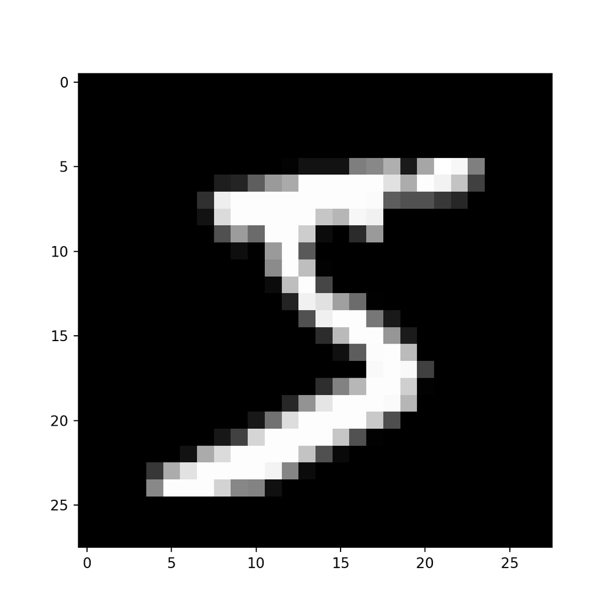

```python
plt.imshow(x_train[0], cmap = "gray")
plt.show()
```

### Graficar las imágenes de los dígitos

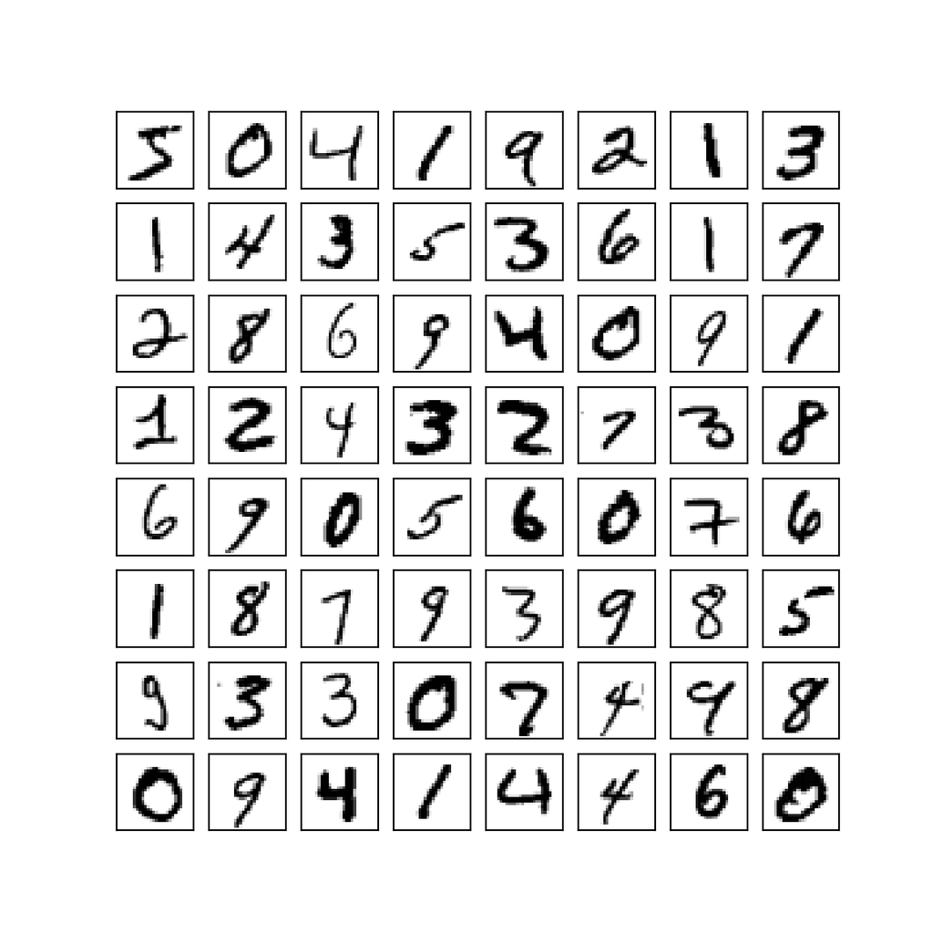

```python
fig, ax = plt.subplots(8, 8, figsize=(6, 6), dpi=100)
for i, axi in enumerate(ax.flat):
    no_imprimir = axi.imshow(x_train[i], cmap='binary', vmin=0, vmax=255)
    no_imprimir = axi.set(xticks=[], yticks=[])
plt.show()
```

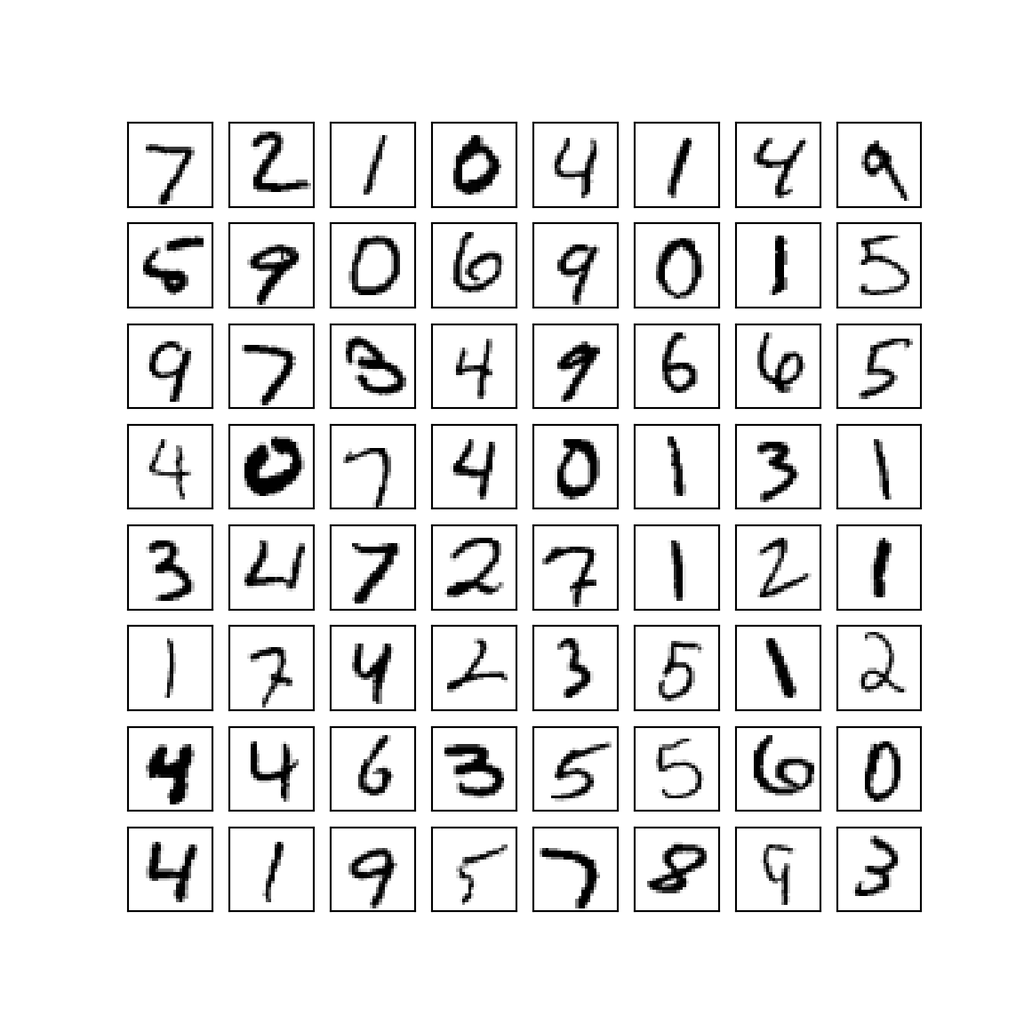

```python
fig, ax = plt.subplots(8, 8, figsize=(6, 6), dpi=100)
for i, axi in enumerate(ax.flat):
    no_imprimir = axi.imshow(x_test[i], cmap='binary', vmin=0, vmax=255)
    no_imprimir = axi.set(xticks=[], yticks=[])
plt.show()
```

### Transformación de datos

```python
# Calculamos la cantidad de etiquetas
num_labels = len(np.unique(y_train))

# Convertimos a l forma one-hot vector
y_train = to_categorical(y_train)
y_test = to_categorical(y_test)

# Dimensiones de entrada de la imagen
image_size = x_train.shape[1]

# Cambiar el tamaño
x_train = np.reshape(x_train,[-1, image_size, image_size, 1])
x_test = np.reshape(x_test,[-1, image_size, image_size, 1])
x_train = x_train.astype('float32') / 255
x_test = x_test.astype('float32') / 255
```

### Estructura de la red

```python
#-----Parámetros por utilizar----
input_shape = (image_size, image_size)
batch_size = 128

# el modelo es RNN con 256 unidades, la entrada es una secuencia de largo 28
# y cada elemento de la secuencia tiene una dimensión de 28
model = Sequential()
model.add(Input(shape = (28, 28)))
model.add(SimpleRNN(units = 256, dropout = 0.2, activation = 'tanh'))
model.add(Dense(num_labels, activation = "softmax"))

# Resumen de la estructura
model.summary()

#Función para graficar un grafo con la estructura de la red neuronal
# Requiere graphviz y pydot
#plot_model(model, to_file='rnn-mnist.png', show_shapes=True)
#img = mpimg.imread('rnn-mnist.png')
#plt.imshow(img)
#plt.show()
```

```
## Model: "sequential_1"
## _________________________________________________________________
##  Layer (type)                Output Shape              Param #
## =================================================================
##  simple_rnn (SimpleRNN)      (None, 256)               72960
##
##  dense_3 (Dense)             (None, 10)                2570
##
## =================================================================
## Total params: 75,530
## Trainable params: 75,530
## Non-trainable params: 0
## _________________________________________________________________
```

### Configuración del modelo

```python
# Función de costo para one-hot vector
model.compile(loss = 'categorical_crossentropy',
              optimizer = 'adam',
              metrics = ['accuracy'])
```

### Entrenamiento y Evaluación

```python
# Entrenamos el modelo
batch_size = 128

model.fit(x_train, y_train, epochs=10, batch_size=batch_size, verbose = 0)
```

```
## <keras.callbacks.History object at 0x7fefa3194220>
```

```python
salida, acc = model.evaluate(x_test,
                             y_test,
                             batch_size=batch_size,
                             verbose=0)

print("\nPrecisión Global: %.1f%%" % (100.0 * acc))
```

```
##
## Precisión Global: 97.1%
```

### Ejemplo de predicción de imágenes

```python
# carga el  mnist dataset
train, (x_test, y_test) = mnist.load_data()

#Estos datos son los que puede procesar el modelo
x_test_model = np.reshape(x_test,[-1, 28, 28, 1])
x_test_model = x_test_model.astype('float32') / 255

print(x_test_model.shape)

#Graficamos los números que vamos a intentar clasificar
```

```
## (10000, 28, 28, 1)
```

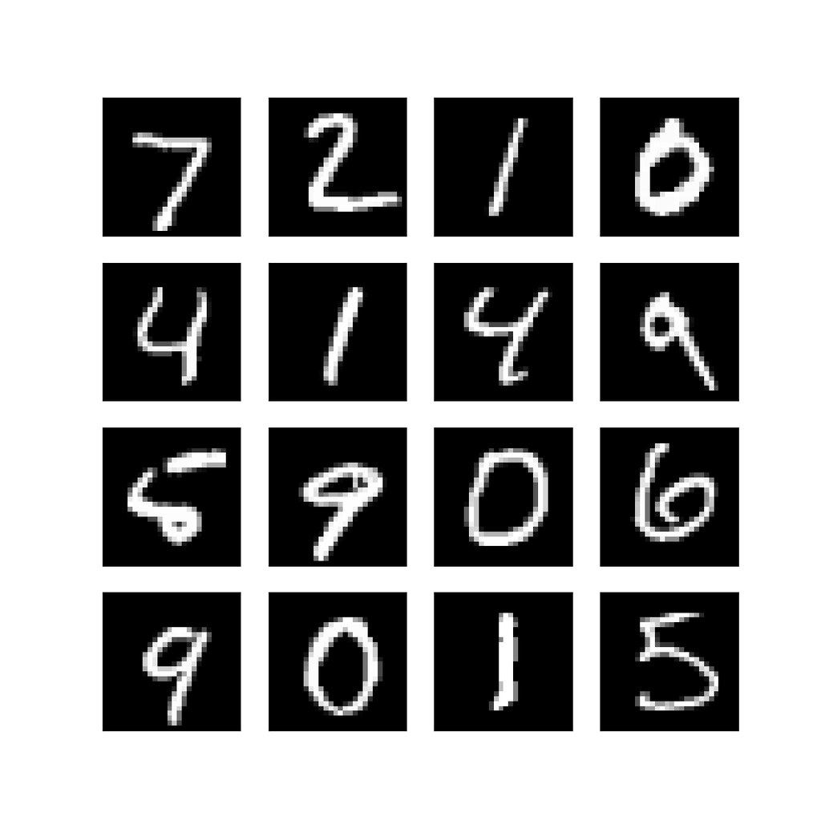

```python
fig, ax = plt.subplots(4, 4, figsize=(6, 6), dpi=100)
for i, axi in enumerate(ax.flat):
    no_imprimir = axi.imshow(x_test[i], cmap = 'gray', vmin=0, vmax=255)
    no_imprimir = axi.set(xticks=[], yticks=[])
plt.show()
```

```python
#Predecimos 16 imágenes
pred = model.predict(x_test_model[0:16])

#Para obtener las "etiquetas"
pred = np.argmax(pred, axis = -1)

#Mostramos las predicciones
print("Predicciones en fila: ",pred,"\n")
```

```
## Predicciones en fila:  [7 2 1 0 4 1 4 9 6 9 0 6 9 0 1 5]
```

```python
print("Predicciones 4x4:\n", np.reshape(pred,[4,4]))
```

```
## Predicciones 4x4:
##  [[7 2 1 0]
##  [4 1 4 9]
##  [6 9 0 6]
##  [9 0 1 5]]
```